# Chrotomys analysis compilation - genera, with Student priors

S.M. Smith

5/2/2022

NEW ANALYSES using Student dist priors. My distributions need to be less easily surprised because TBA is pretty variable.

Load up Chrotomyini trabecular bone architecture (TBA) data and standardize variables:

```r
d <- read.csv(file = "G:\\My Drive\\Philippine rodents\\chrotomyini\\05062022 Philippine Murids segmentation parameters and morphological data - TBA data total BoneJ (full).csv", header = T)

d <- d[d$tribe=="chroto",c(1:2, 4:23)]

d <-
  d %>%
  mutate(bvtv = as.numeric(bvtv))

d <-
  d %>%
  mutate(mass_s = rethinking::standardize(log10(mass_g)),
         elev_s = rethinking::standardize(elev),
         bvtv_s = rethinking::standardize(bvtv),
         tbth_s = rethinking::standardize(tbth),
         tbsp_s = rethinking::standardize(tbsp),
         conn_s = rethinking::standardize(conn),
         cond_s = rethinking::standardize(m_connd),
         cond_s2 = rethinking::standardize(connd),
         da_s = rethinking::standardize(da))

# remove C. gonzalesi and R. isarogensis, singletons:
d <-
  d %>%
  filter(taxon!="Chrotomys_gonzalesi") %>%
  filter(taxon!="Rhynchomys_isarogensis")

# Make categorical vars into factors
d <-
  d %>%
  mutate(loco = factor(loco),
         hab_simp = factor(hab_simp),
         genus = factor(genus))

# Specify colors for plots:
cols = c("#86acca","#ab685b", "#3370a3", "#1f314c","#5a9fa8")
```

Load in phylogeny: REMEMBER: A <- ape::vcv.phylo(phylo), add corr = T if your tree is NOT SCALED TO 1.

```r
ch.tre <- read.nexus(file = "G:\\My Drive\\Philippine rodents\\Chrotomys\\analysis\\SMS_PRUNED_and_COLLAPSED_03292022_OTUsrenamed_Rowsey_PhBgMCC_LzChrotomyini.nex")

ch <- ape::vcv.phylo(ch.tre, corr = T)

d <-
  d %>%
  mutate(phylo = taxon)
```

#### Comparisons of several models for each trabecular bone metric

Same analyses as before, but this time with Student’s dist priors. For reference: https://solomonkurz.netlify.app/post/2019-02-02-robust-linear-regression-with-student-s-t-distribution/ https://solomonkurz.netlify.app/post/2019-02-10-bayesian-robust-correlations-with-brms-and-why-you-should-love-student-s-t/

#### Bone Volume Fraction (BV.TV)

```r
# BV.TV by mass
ch.70 <-
  brm(data = d,
      family = student,
      bvtv_s ~ 1+mass_s,
      prior = c(prior(normal(0, 1), class = b),
                prior(gamma(2, 0.1), class = nu),
                prior(exponential(1), class = sigma)),
      iter = 2000, warmup = 1000, chains = 4, cores = 4,
      seed = 5,
      file = "G:\\My Drive\\Philippine rodents\\chrotomyini\\fits\\ch.70")
print(ch.70)
```

```
##  Family: student
##   Links: mu = identity; sigma = identity; nu = identity
## Formula: bvtv_s ~ 1 + mass_s
##    Data: d (Number of observations: 67)
##   Draws: 4 chains, each with iter = 2000; warmup = 1000; thin = 1;
##          total post-warmup draws = 4000
##
## Population-Level Effects:
##           Estimate Est.Error l-95% CI u-95% CI Rhat Bulk_ESS Tail_ESS
## Intercept    -0.03      0.10    -0.23     0.19 1.00     4399     3019
## mass_s        0.55      0.11     0.34     0.76 1.00     3955     2435
##
## Family Specific Parameters:
##       Estimate Est.Error l-95% CI u-95% CI Rhat Bulk_ESS Tail_ESS
## sigma     0.80      0.08     0.67     0.97 1.00     4291     2986
## nu       25.90     14.48     6.94    62.97 1.00     4444     2757
##
## Draws were sampled using sampling(NUTS). For each parameter, Bulk_ESS
## and Tail_ESS are effective sample size measures, and Rhat is the potential
## scale reduction factor on split chains (at convergence, Rhat = 1).
```

A scatterplot of thTe above model, with genera color-coded (the same color code to be used for the remainder of this document):

```r
range(d$mass_s)
```

```
## [1] -1.866104  1.451091
```

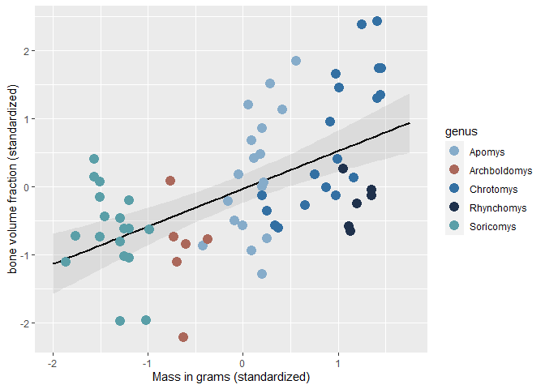

```r
nd <- tibble(mass_s = seq(from = -2, to = 1.75, length.out = 67))

fitted(ch.70,
       newdata = nd) %>%
  data.frame() %>%
  bind_cols(nd) %>%

  # plot
  ggplot(aes(x = mass_s)) +
  geom_smooth(aes(y = Estimate, ymin = Q2.5, ymax = Q97.5),
              stat = "identity",
              alpha = 1/5, size = 1, color = "black") +
  geom_point(data = d, aes(y = bvtv_s, color = genus), size = 4)+
  scale_color_manual(values = cols)+
  xlim(min(nd), max(nd))+
  labs(x = "Mass in grams (standardized)",
       y = "bone volume fraction (standardized)")
```

Testing across metrics:

```r
# By genus only
ch.71 <-
  brm(data = d,
      family = student,
      bvtv_s ~ 0 + genus,
      prior = c(prior(normal(0, 1), class = b),
                prior(gamma(2, 0.1), class = nu),
                prior(exponential(1), class = sigma)),
      iter = 2000, warmup = 1000, chains = 4, cores = 4,
      file = "G:\\My Drive\\Philippine rodents\\chrotomyini\\fits\\ch.71")
print(ch.71)
```

```
##  Family: student
##   Links: mu = identity; sigma = identity; nu = identity
## Formula: bvtv_s ~ 0 + genus
##    Data: d (Number of observations: 67)
##   Draws: 4 chains, each with iter = 2000; warmup = 1000; thin = 1;
##          total post-warmup draws = 4000
##
## Population-Level Effects:
##                   Estimate Est.Error l-95% CI u-95% CI Rhat Bulk_ESS Tail_ESS
## genusApomys           0.17      0.20    -0.23     0.55 1.00     6709     2898
## genusArchboldomys    -0.81      0.32    -1.44    -0.18 1.00     6269     2844
## genusChrotomys        0.67      0.20     0.28     1.06 1.00     6094     2773
## genusRhynchomys      -0.21      0.32    -0.83     0.41 1.00     6533     2746
## genusSoricomys       -0.62      0.19    -1.00    -0.25 1.00     6524     2828
##
## Family Specific Parameters:
##       Estimate Est.Error l-95% CI u-95% CI Rhat Bulk_ESS Tail_ESS
## sigma     0.80      0.08     0.66     0.98 1.00     5172     3253
## nu       25.20     14.42     6.49    61.25 1.00     5318     2992
##
## Draws were sampled using sampling(NUTS). For each parameter, Bulk_ESS
## and Tail_ESS are effective sample size measures, and Rhat is the potential
## scale reduction factor on split chains (at convergence, Rhat = 1).
```

```r
# By genus and mass
ch.72 <-
  brm(data = d,
      family = student,
      bvtv_s ~ 0 + genus + mass_s,
      prior = c(prior(normal(0, 1), class = b),
                prior(gamma(2, 0.1), class = nu),
                prior(exponential(1), class = sigma)),
      iter = 2000, warmup = 1000, chains = 4, cores = 4,
      file = "G:\\My Drive\\Philippine rodents\\chrotomyini\\fits\\ch.72")
print(ch.72)
```

```
##  Family: student
##   Links: mu = identity; sigma = identity; nu = identity
## Formula: bvtv_s ~ 0 + genus + mass_s
##    Data: d (Number of observations: 67)
##   Draws: 4 chains, each with iter = 2000; warmup = 1000; thin = 1;
##          total post-warmup draws = 4000
##
## Population-Level Effects:
##                   Estimate Est.Error l-95% CI u-95% CI Rhat Bulk_ESS Tail_ESS
## genusApomys           0.06      0.18    -0.28     0.41 1.00     4182     2646
## genusArchboldomys    -0.26      0.33    -0.91     0.40 1.00     2631     2719
## genusChrotomys       -0.25      0.29    -0.80     0.34 1.00     1566     2198
## genusRhynchomys      -1.34      0.41    -2.14    -0.52 1.00     1773     2337
## genusSoricomys        0.74      0.39    -0.06     1.50 1.00     1386     2086
## mass_s                1.02      0.26     0.48     1.51 1.00     1333     1784
##
## Family Specific Parameters:
##       Estimate Est.Error l-95% CI u-95% CI Rhat Bulk_ESS Tail_ESS
## sigma     0.71      0.07     0.57     0.87 1.00     2346     2466
## nu       23.82     14.22     6.23    60.65 1.00     3074     2489
##
## Draws were sampled using sampling(NUTS). For each parameter, Bulk_ESS
## and Tail_ESS are effective sample size measures, and Rhat is the potential
## scale reduction factor on split chains (at convergence, Rhat = 1).
```

```r
# By genus, mass, and phylogeny

ch.74.1 <-
  brm(data = d,
      family = student,
      bvtv_s ~ 0 + genus + mass_s + (1|gr(phylo, cov = ch)),
      control = list(adapt_delta = 0.85), #inserted to decrease the number of divergent transitions here
      prior = c(
        prior(gamma(2, 0.1), class = nu),
        prior(normal(0, 1), class = b, coef = genusApomys),
        prior(normal(0, 1), class = b, coef = genusArchboldomys),
        prior(normal(0, 1), class = b, coef = genusChrotomys),
        prior(normal(0, 1), class = b, coef = genusRhynchomys),
        prior(normal(0, 1), class = b, coef = genusSoricomys),
        prior(normal(0, 1), class = b, coef = mass_s),
        prior(normal(0, 1), class = sd),
        prior(exponential(1), class = sigma)
        ),
      data2 = list(ch = ch),
      iter = 2000, warmup = 1000, chains = 4, cores = 4,
      file = "G:\\My Drive\\Philippine rodents\\chrotomyini\\fits\\ch.74.1")
print(ch.74.1)
```

```
##  Family: student
##   Links: mu = identity; sigma = identity; nu = identity
## Formula: bvtv_s ~ 0 + genus + mass_s + (1 | gr(phylo, cov = ch))
##    Data: d (Number of observations: 67)
##   Draws: 4 chains, each with iter = 2000; warmup = 1000; thin = 1;
##          total post-warmup draws = 4000
##
## Group-Level Effects:
## ~phylo (Number of levels: 11)
##               Estimate Est.Error l-95% CI u-95% CI Rhat Bulk_ESS Tail_ESS
## sd(Intercept)     0.74      0.26     0.28     1.34 1.00     1535     1758
##
## Population-Level Effects:
##                   Estimate Est.Error l-95% CI u-95% CI Rhat Bulk_ESS Tail_ESS
## genusApomys           0.11      0.53    -0.95     1.21 1.00     2441     2327
## genusArchboldomys    -0.23      0.62    -1.45     1.02 1.00     3232     2863
## genusChrotomys       -0.09      0.59    -1.24     1.06 1.00     2173     2454
## genusRhynchomys      -0.77      0.67    -2.04     0.61 1.00     2675     2961
## genusSoricomys        0.38      0.65    -0.91     1.63 1.00     2593     2643
## mass_s                0.81      0.29     0.23     1.37 1.00     2856     2777
##
## Family Specific Parameters:
##       Estimate Est.Error l-95% CI u-95% CI Rhat Bulk_ESS Tail_ESS
## sigma     0.62      0.08     0.46     0.78 1.00     2370     1643
## nu       19.44     13.33     3.76    53.78 1.00     2861     1710
##
## Draws were sampled using sampling(NUTS). For each parameter, Bulk_ESS
## and Tail_ESS are effective sample size measures, and Rhat is the potential
## scale reduction factor on split chains (at convergence, Rhat = 1).
```